# Time Varying Regression Lab 2

# Load the data

```r
load("landings.RData")
landings$log.metric.tons = log(landings$metric.tons)
landings = subset(landings, Year <= 1987)
```

Add `t` to the data. This is Year minus first Year.

```r
landings$t = landings$Year-landings$Year[1]
```

We will look at sardines and a 4th order polynomial. h is the forecast length. h=5 is 5 years.

```r
val <- "Sardine"
poly.order <- 4
h <- 5
```

# Fit linear regression

Use the poly function

$$log(Sardine catch) = \alpha + \beta t + \beta_2 t^2 + \beta_3 t^3 + \beta_4 t^4 + e_t$$

```r
model <- lm(log.metric.tons ~ poly(t, poly.order), data=landings, subset=Species==val)
```

# Create a forecast

Use the `predict()` function. First you must set up the newdata data.frame. This is specific to the `predict()` function. Let’s predict for the next 5 t after the end of the data.

```r
dat <- subset(landings, Species==val)
dat$t
```

```
##  [1]  0  1  2  3  4  5  6  7  8  9 10 11 12 13 14 15 16 17 18 19 20 21 22
## [24] 23
```

The newdata data.frame must have the name the same as your predictor `t` and have the values at the `t` you want to forecast.

```r
last.t <- max(dat$t)
nd <- data.frame(t = last.t + 1:h)
```

Now you can predict:

```r
predict(model, newdata = nd)
```

```
##        1        2        3        4        5
## 9.241230 9.293302 9.387034 9.532185 9.739329
```

That is for years

```r
max(dat$Year) + 1:h
```

```
## [1] 1988 1989 1990 1991 1992
```

# Show the prediction intervals on your forecast

You can use predict for this too. `lwr` is the lower 95% prediction and upr is the upper 95% prediction.

```r
predict(model, newdata = nd, interval="prediction")
```

```
##        fit      lwr       upr
## 1 9.241230 8.946917  9.535543
## 2 9.293302 8.881264  9.705340
## 3 9.387034 8.802235  9.971834
## 4 9.532185 8.714969 10.349401
## 5 9.739329 8.623837 10.854821
```

# Make a nicer table of predictions

Show in metric tons instead of log metric tons.

```r
pr <- predict(model, newdata = nd, interval="prediction")
pr <- as.data.frame(exp(pr))
pr$Year <- max(dat$Year) + 1:h
```

Make table in R markdown

```r
library(knitr)
kable(pr)
```

| fit | lwr | upr | Year |
| --- | --- | --- | --- |
| 10313.72 | 7684.167 | 13843.11 | 1988 |
| 10865.00 | 7195.879 | 16404.98 | 1989 |
| 11932.66 | 6649.086 | 21414.72 | 1990 |
| 13796.70 | 6093.444 | 31238.33 | 1991 |
| 16972.15 | 5562.689 | 51783.21 | 1992 |

# Create plots of forecasts

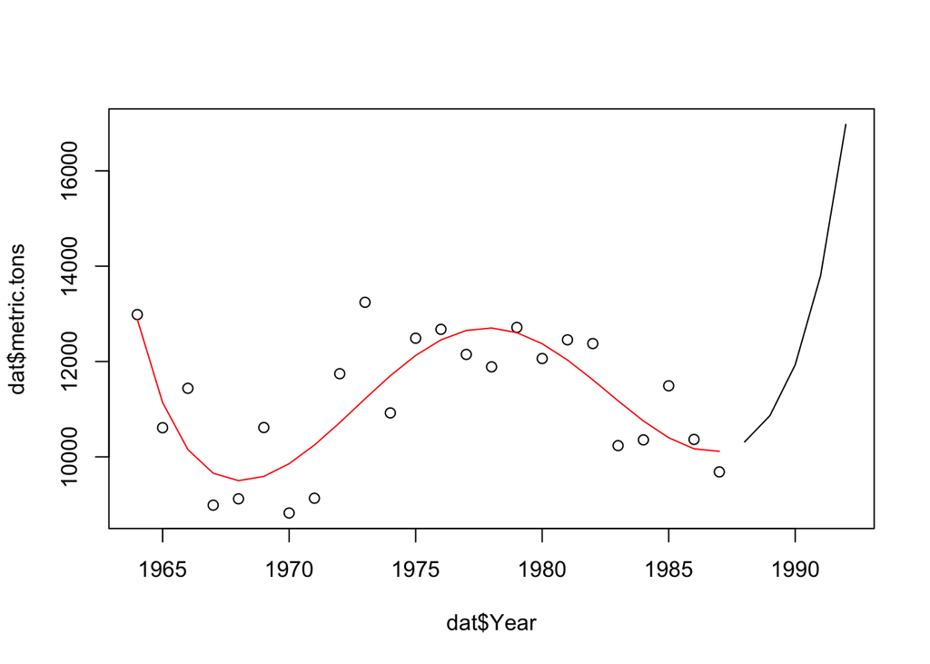

```r
pr <- predict(model, newdata = nd, interval="prediction")
pr <- as.data.frame(exp(pr))
ylims <- c(min(dat$metric.tons, pr$fit), max(dat$metric.tons, pr$fit))
pr$Year <- max(dat$Year) + 1:h
plot(dat$Year, dat$metric.tons, xlim=c(min(dat$Year), max(dat$Year)+h),
     ylim=ylims)
lines(dat$Year, exp(fitted(model)), col="red")
lines(pr$Year, pr$fit)
```

You can plot with

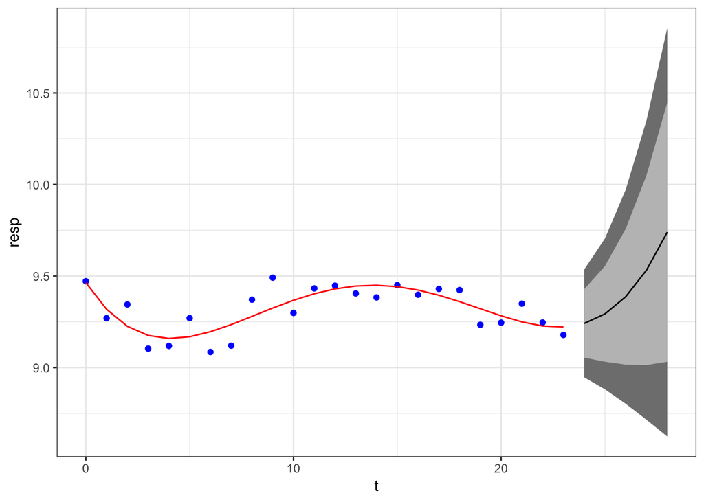

```r
plotforecasttv(model)
```

# The problem with high order polynomials

You model fits the data nicely, but your forecasts are very uncertain as you move farther out. This is a property of very flexible models. They fit the data, but tend to overfit so forecasts are more not less uncertain.

# Problems

1. Fit a 1st order polynomial to the sardine data. Create a forecast for 10 years into the future.
2. Create forecasts for one of the other species.

```r
unique(landings$Species)
```

```
## [1] Anchovy        Sardine        Chub.mackerel  Horse.mackerel
## [5] Mackerel       Jack.Mackerel
## 6 Levels: Anchovy Sardine Chub.mackerel Horse.mackerel ... Jack.Mackerel
```